title: “FinalWriteUp” author: “Apache Juntion Armchairs: Ellie, Ryan, Sude and Darren” date: “4/20/2020” output: pdf_document: fig_width: 5 fig_height: 3 —

Section 1: Introduction

Section 2: Regression Analysis:

manually imputing the mean value for homeprice and income, and setting Na values of PP change variables to zero.

### EXPLORATORY DATA ANALYSIS

The distribution of change in Black population:

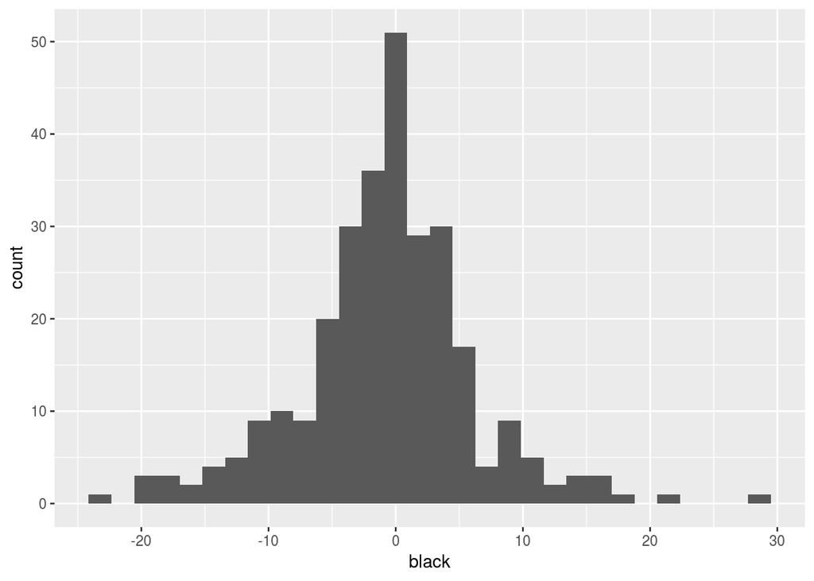

```
## [1] 6.88333
```

```
## # A tibble: 2 x 2
##    gent     n
##   <dbl> <int>
## 1     0   244
## 2     1    44
```

More Univariate EDA:

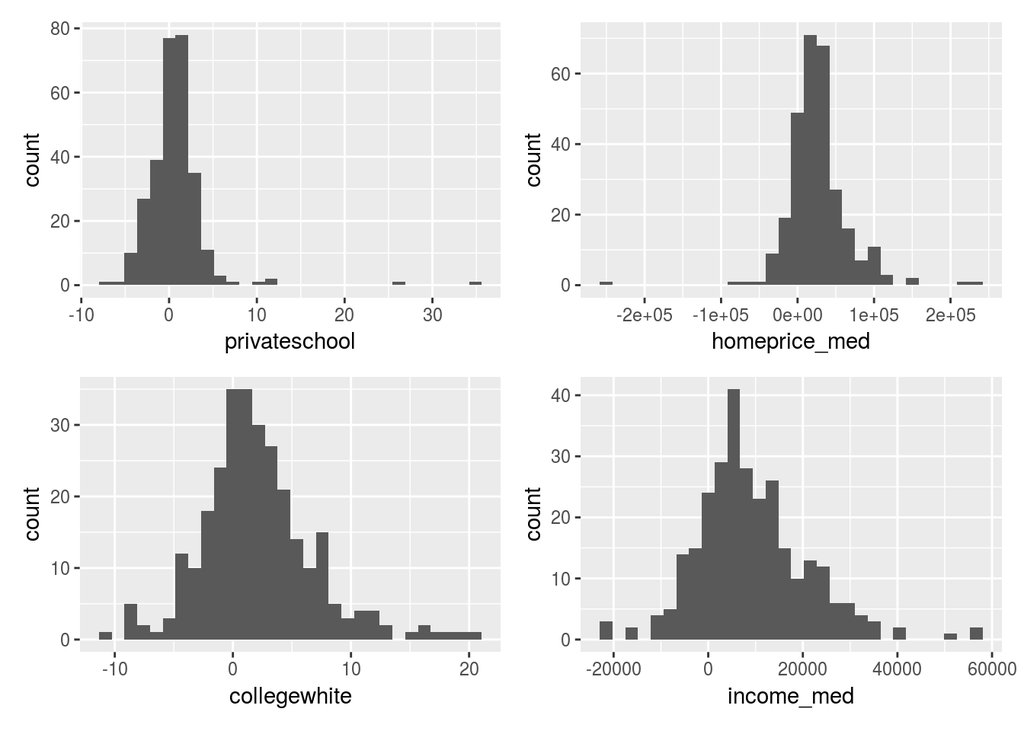

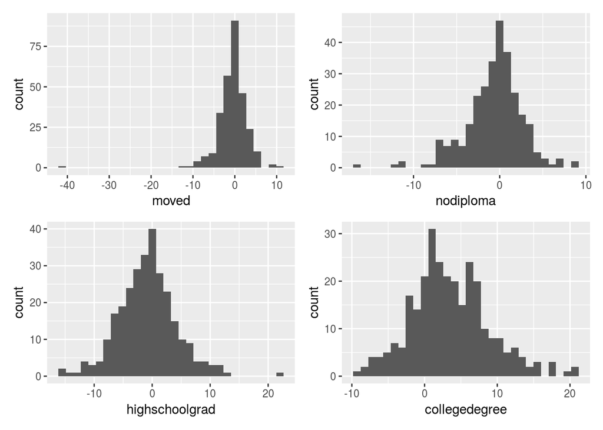

Bivariate EDA:

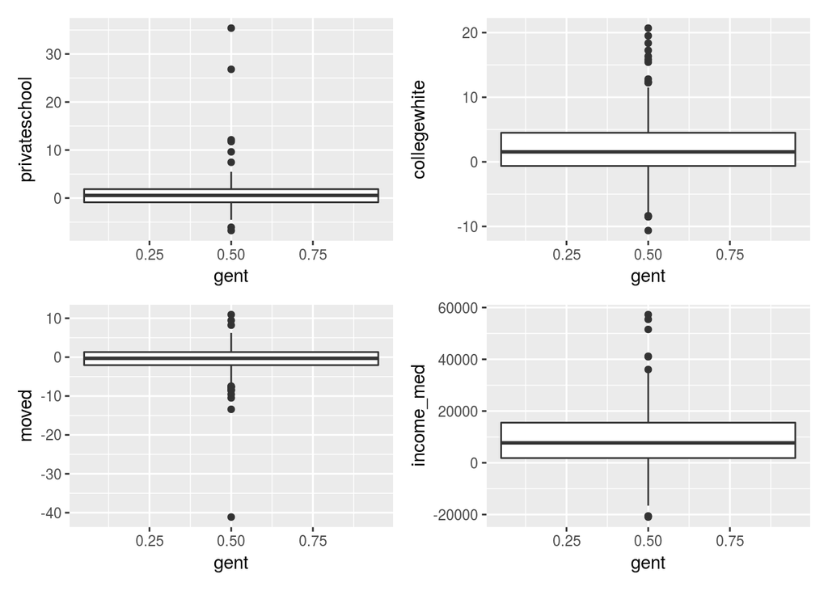

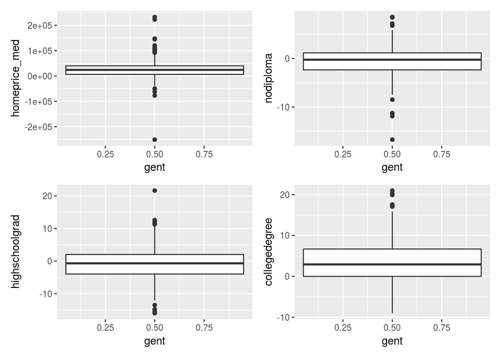

###Part I: Location of Gentrification

In part I, the following research question will be examined:

Where in the Research Triangle (counties including Durham, Wake, Orange and Chatham) is gentrification occurring the most?

```
## # A tibble: 2 x 2
##    gent     n
##   <dbl> <int>
## 1     0   244
## 2     1    44
```

Reading in spatial data

Plotting research triangle area:

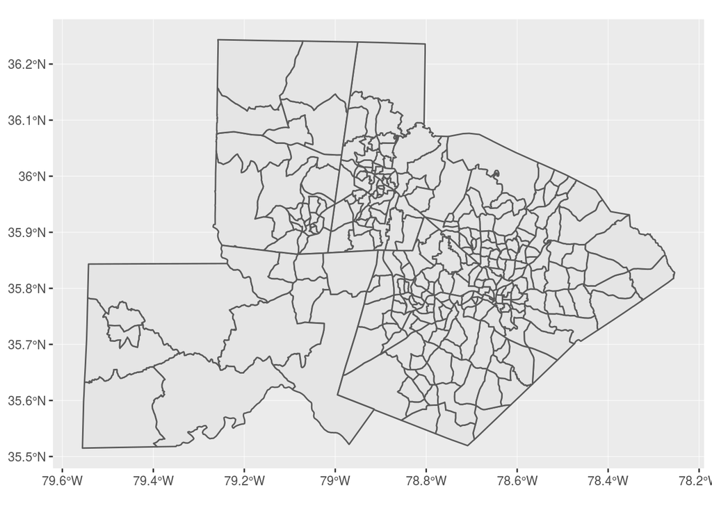

Plotting research triangle area by which regions have experienced gentrification:

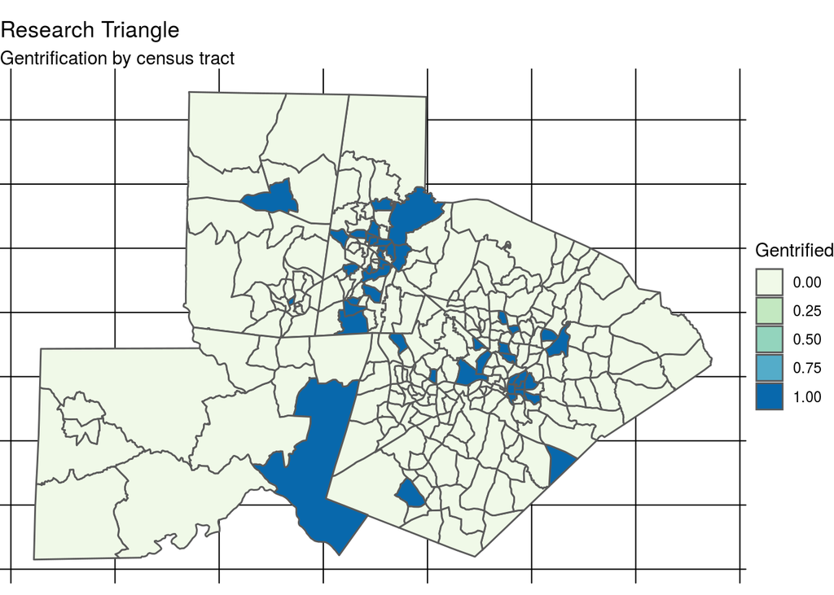

#Plotting urban areas by census tract:

Converting “rural” into a binary variable.

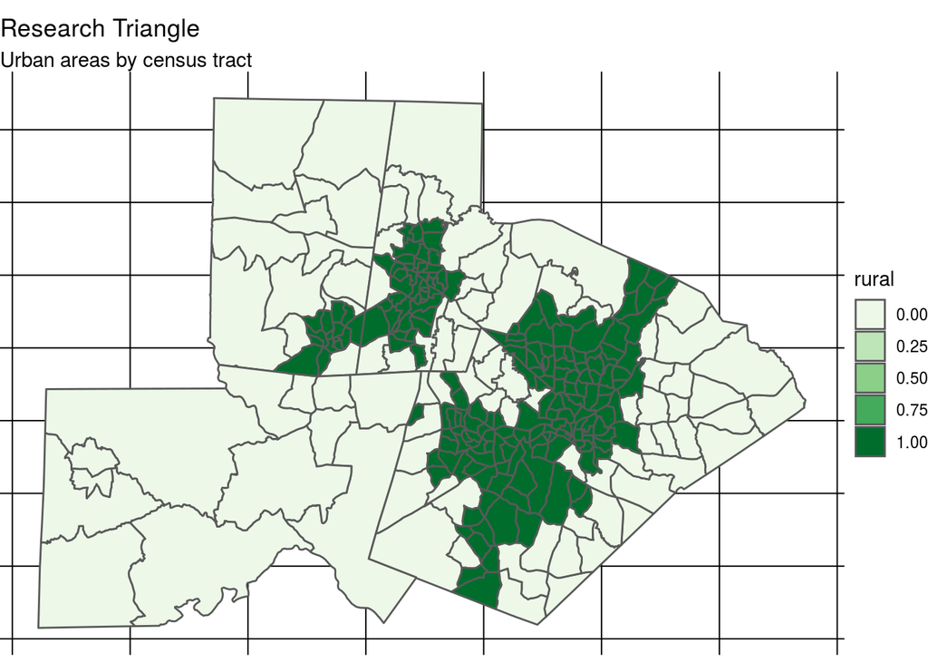

By comparing the locations of gentrified tracts to urban areas, we can see that almost all gentrified tracts are in urban areas. Moreover, many of the gentrified tracts appear to be in and around city centers. This makes sense–we tend to think of gentrification as affecting highly urbanized downtown areas.

###Part 2: Factors Associated with Gentrification

In part 2, the following research question will be examined:

What factors are associated with and what are the strongest predictors of the gentrification of these areas?

##Using Logistic Regression

Creating the logistic model using mutated variable “gent” as our response variable:

| term | estimate | std.error | statistic | p.value | conf.low | conf.high |
| --- | --- | --- | --- | --- | --- | --- |
| (Intercept) | -3.00216 | 1.76126 | -1.70455 | 0.08828 | -6.50546 | 0.42759 |
| collegewhite | 0.14487 | 0.06063 | 2.38927 | 0.01688 | 0.02889 | 0.26801 |
| whitecollar | -0.05600 | 0.03098 | -1.80772 | 0.07065 | -0.11837 | 0.00337 |
| privateschool | 0.01855 | 0.05029 | 0.36882 | 0.71226 | -0.09732 | 0.10785 |
| nodiploma | 0.12286 | 0.06408 | 1.91736 | 0.05519 | 0.00077 | 0.25299 |
| highschoolgrad | 0.05705 | 0.04424 | 1.28955 | 0.19721 | -0.02836 | 0.14590 |
| collegedegree | -0.03647 | 0.06220 | -0.58638 | 0.55762 | -0.16062 | 0.08438 |
| income_med | -0.00002 | 0.00002 | -0.86680 | 0.38605 | -0.00005 | 0.00002 |
| homeprice_med | 0.00001 | 0.00000 | 2.44891 | 0.01433 | 0.00000 | 0.00002 |
| early_late | -0.00940 | 0.01852 | -0.50727 | 0.61197 | -0.04578 | 0.02715 |
| moved | 0.00344 | 0.04475 | 0.07697 | 0.93865 | -0.07898 | 0.10019 |

Using backward selection to find the optimal model:

```
## Start:  AIC=241.3
## gent ~ collegewhite + whitecollar + privateschool + nodiploma +
##     highschoolgrad + collegedegree + income_med + homeprice_med +
##     early_late + moved
##
##                  Df Deviance    AIC
## - moved           1   219.31 239.31
## - privateschool   1   219.43 239.43
## - early_late      1   219.56 239.56
## - collegedegree   1   219.65 239.65
## - income_med      1   220.07 240.07
## - highschoolgrad  1   221.00 241.00
## <none>                219.30 241.30
## - whitecollar     1   222.71 242.71
## - nodiploma       1   223.19 243.19
## - collegewhite    1   225.34 245.34
## - homeprice_med   1   225.64 245.64
##
## Step:  AIC=239.31
## gent ~ collegewhite + whitecollar + privateschool + nodiploma +
##     highschoolgrad + collegedegree + income_med + homeprice_med +
##     early_late
##
##                  Df Deviance    AIC
## - privateschool   1   219.44 237.44
## - early_late      1   219.56 237.56
## - collegedegree   1   219.66 237.66
## - income_med      1   220.08 238.08
## - highschoolgrad  1   221.00 239.00
## <none>                219.31 239.31
## - whitecollar     1   222.73 240.73
## - nodiploma       1   223.19 241.19
## - collegewhite    1   225.38 243.38
## - homeprice_med   1   225.65 243.65
##
## Step:  AIC=237.44
## gent ~ collegewhite + whitecollar + nodiploma + highschoolgrad +
##     collegedegree + income_med + homeprice_med + early_late
##
##                  Df Deviance    AIC
```

[output cut: 33 more lines]

```
## - nodiploma       1   224.51 236.51
## - homeprice_med   1   226.87 238.87
## - collegewhite    1   228.82 240.82
##
## Step:  AIC=232.93
## gent ~ collegewhite + whitecollar + nodiploma + highschoolgrad +
##     homeprice_med
##
##                  Df Deviance    AIC
## <none>                220.93 232.93
## - highschoolgrad  1   224.01 234.01
## - whitecollar     1   224.36 234.36
## - nodiploma       1   225.70 235.70
## - homeprice_med   1   226.98 236.98
## - collegewhite    1   228.92 238.92
```

| term | estimate | std.error | statistic | p.value | conf.low | conf.high |
| --- | --- | --- | --- | --- | --- | --- |
| (Intercept) | -2.23080 | 0.24515 | -9.09985 | 0.00000 | -2.74176 | -1.77646 |
| collegewhite | 0.10841 | 0.03943 | 2.74954 | 0.00597 | 0.03290 | 0.18858 |
| whitecollar | -0.05692 | 0.03137 | -1.81461 | 0.06958 | -0.11996 | 0.00321 |
| nodiploma | 0.13470 | 0.06339 | 2.12476 | 0.03361 | 0.01355 | 0.26289 |
| highschoolgrad | 0.06938 | 0.04021 | 1.72554 | 0.08443 | -0.00792 | 0.15022 |
| homeprice_med | 0.00001 | 0.00000 | 2.37718 | 0.01745 | 0.00000 | 0.00002 |

Creating a full model to determine if we should add “rural” to the model:

```
## # A tibble: 7 x 5
##   term             estimate  std.error statistic  p.value
##   <chr>               <dbl>      <dbl>     <dbl>    <dbl>
## 1 (Intercept)    -2.88      0.450          -6.39 1.64e-10
## 2 collegewhite    0.0939    0.0400          2.35 1.88e- 2
## 3 whitecollar    -0.0546    0.0318         -1.72 8.61e- 2
## 4 nodiploma       0.118     0.0631          1.87 6.16e- 2
## 5 highschoolgrad  0.0606    0.0406          1.49 1.35e- 1
## 6 homeprice_med   0.0000108 0.00000468      2.31 2.10e- 2
## 7 ruralUrban      0.891     0.476           1.87 6.12e- 2
```

Drop in deviance test:

```
## [1] 220.9284
```

```
## [1] 216.9145
```

```
## [1] 4.013908
```

p-value:

```
## [1] 0.04512643
```

Since the chisq p-value for adding “Rural” to the model is less than .05, we reject the null hypothesis that “Rural” is not a significant predictor of whether or not a region has experienced gentrification.

Therefore we will continue with this full model for the remained of our analysis.

Checking multicollinearity

```
## # A tibble: 6 x 2
##   names              x
##   <chr>          <dbl>
## 1 collegewhite    1.53
## 2 whitecollar     1.17
## 3 nodiploma       1.16
## 4 highschoolgrad  1.41
## 5 homeprice_med   1.18
## 6 ruralUrban      1.03
```

heat map of residuals for independence

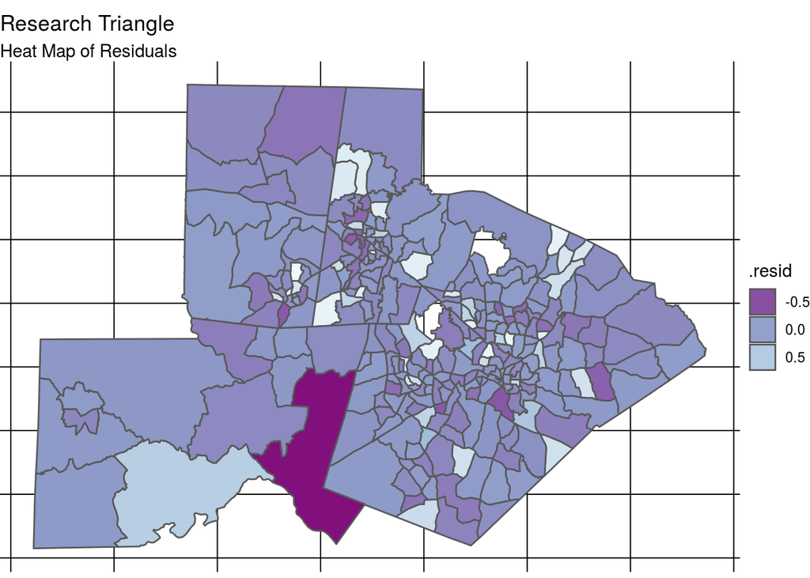

###Assumptions

In order to use the full model with the predictor variables collegewhite, whitecollar, nodiploma, highschoolgrad, homeprice_med, and rural, we must first test how well this model satisfies assumptions.

For testing linearity, we will augment the model with predicted probabilities and residuals in order to examine binned residual plots for predicted probability and numeric variables.

```
## # A tibble: 285 x 15
##    .rownames  gent collegewhite whitecollar nodiploma highschoolgrad
##  * <chr>     <dbl>        <dbl>       <dbl>     <dbl>          <dbl>
##  1 1             0       -8.46        -16.4    7.20           -4.89
##  2 2             0        2.96          3.2   -0.640          -0.658
##  3 3             0       -0.735         4.3    0.807          -1.44
##  4 4             0       -4.08          6.6    0.0800         -1.86
##  5 5             0        2.31         -2.8    1.16           -4.08
##  6 6             0       -1.25          0.5   -0.388          -4.55
##  7 7             0       -0.224         4.3   -7.19            5.87
##  8 8             0        2.17         18.4   -5.19           11.3
##  9 9             0       -1.92         -5.6    2.05            0.321
## 10 10            0        5.44          6.9   -0.837           0.687
## # ... with 275 more rows, and 9 more variables: homeprice_med <dbl>,
## #   rural <chr>, .fitted <dbl>, .se.fit <dbl>, .resid <dbl>, .hat <dbl>,
## #   .sigma <dbl>, .cooksd <dbl>, .std.resid <dbl>
```

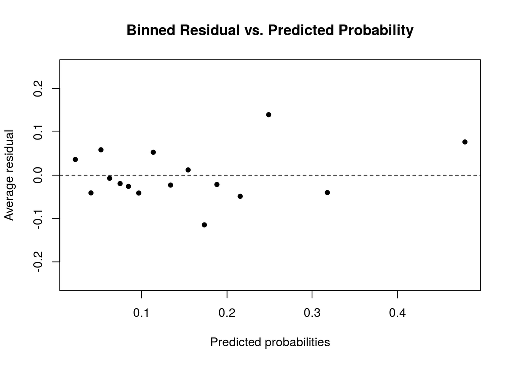

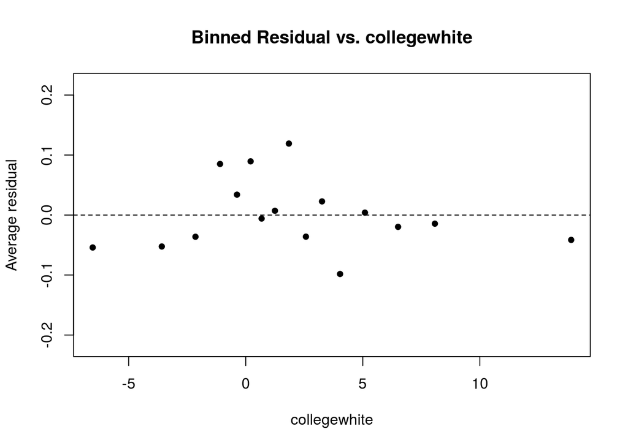

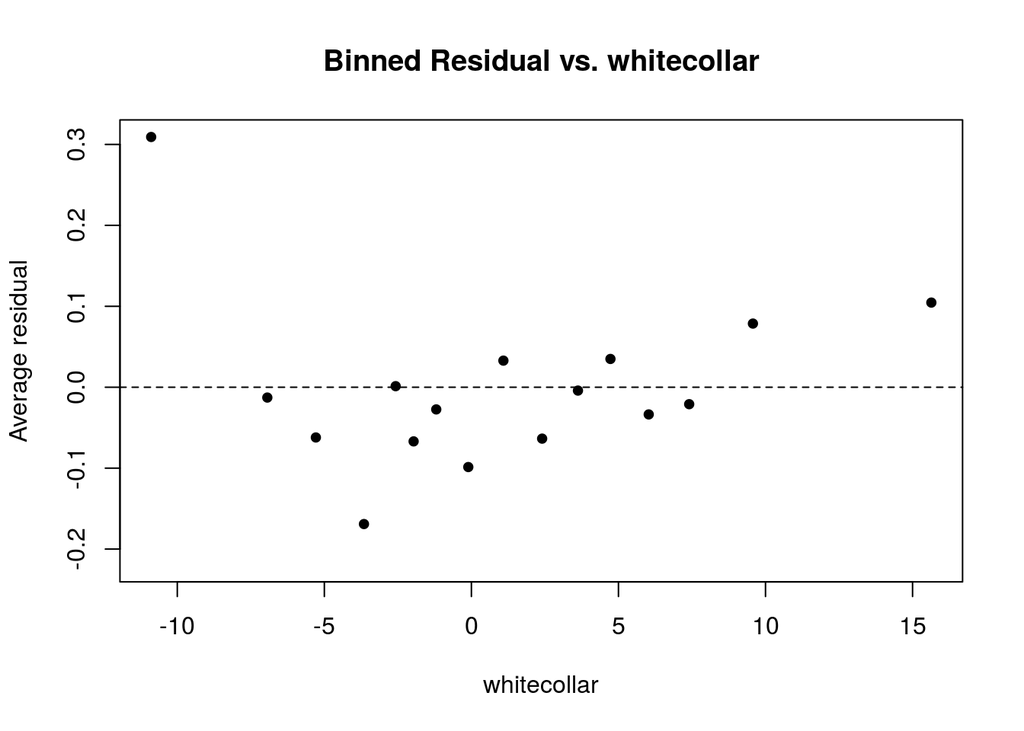

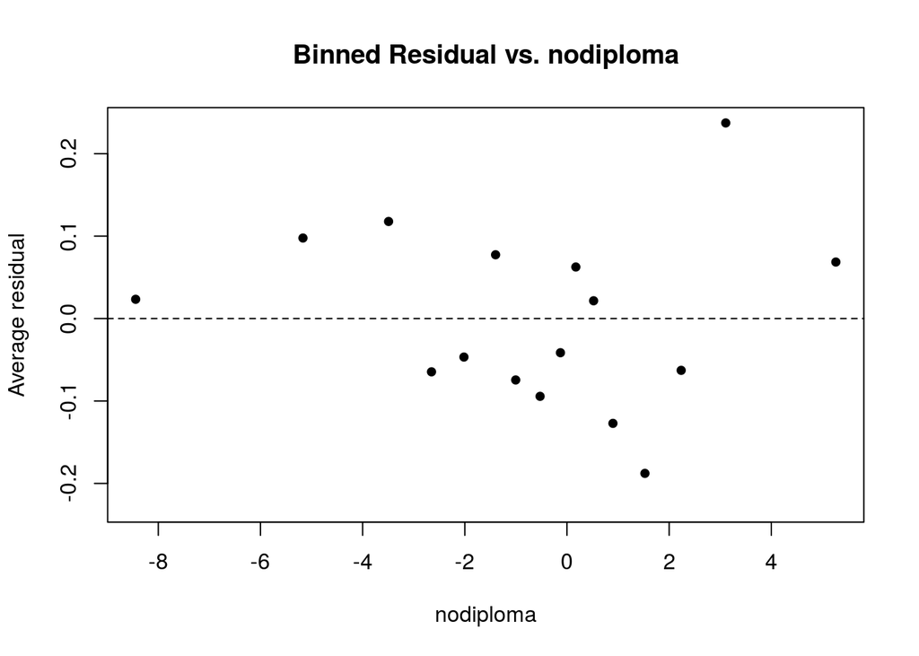

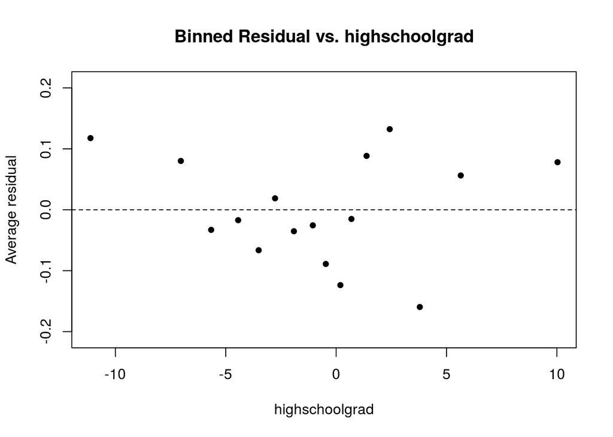

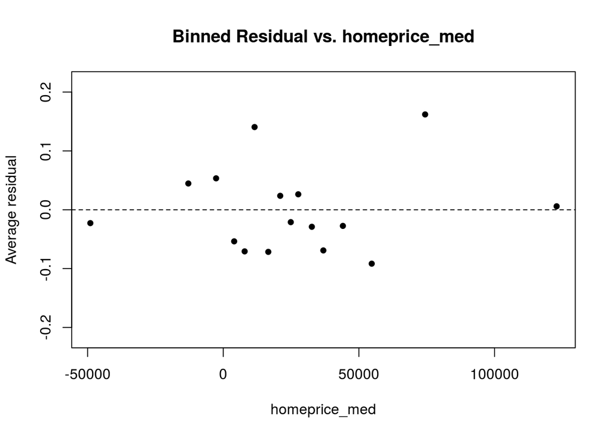

```
## # A tibble: 2 x 2
##   rural mean_resid
##   <chr>      <dbl>
## 1 Rural  -5.38e-11
## 2 Urban  -4.71e-12
```

The linearity assumption is satisfied. The binned residuals vs. predicted probability plot shows irregularity with a very slight clustering of residual values below 0.0. The binned residuals vs. collegewhite plot shows irregularity. The binned residuals vs. whitecollar plot shows irregularity, with a slight clustering of residual values below 0.0 and a slight increase in residual values as you move right. The binned residuals vs. nodiploma, binned residuals vs. highschoolgrad, and binned residuals vs. homeprice_med show complete irregularity. For the predictor variable rural, which has two categories rural and urban, both mean residuals are very close to zero. There is no strong indication of nonlinearity; therefore, we can assume that there is a linear relationship between log(gent) and the predictor variables.

To discuss randomness and independence, we must go back to the source of our data. All of the data we are using is sourced from the Census Bureau’s annual American Community Survey and official North Carolina demographic data. According to the census sampling techniques and methodology, we can reasonably assume that randomness and independence are satisfied. Read more here: https://www.census.gov/programs-surveys/sipp/methodology.html

### Interpreting Model Coefficients

Now that we’ve confirmed that it satisfies assumptions, let’s take a look at our chosen logistic model again:

| term | estimate | std.error | statistic | p.value | conf.low | conf.high |
| --- | --- | --- | --- | --- | --- | --- |
| (Intercept) | -2.877 | 0.450 | -6.392 | 0.000 | -3.867 | -2.076 |
| collegewhite | 0.094 | 0.040 | 2.349 | 0.019 | 0.017 | 0.175 |
| whitecollar | -0.055 | 0.032 | -1.716 | 0.086 | -0.119 | 0.006 |
| nodiploma | 0.118 | 0.063 | 1.869 | 0.062 | -0.002 | 0.246 |
| highschoolgrad | 0.061 | 0.041 | 1.494 | 0.135 | -0.018 | 0.142 |
| homeprice_med | 0.000 | 0.000 | 2.309 | 0.021 | 0.000 | 0.000 |
| ruralUrban | 0.891 | 0.476 | 1.872 | 0.061 | 0.018 | 1.915 |